# Exploratory Data Analysis: White Wine Quality

Brian Novak

February 27, 2019

# Single variables

### Acid concentrations

##### Tartaric acid concentration (fixed acidity)

The distribution of tartaric acid concentration is fairly symmetric, with only 7 wines having a high acidity with 10 grams/liter of tartaric acid or higher.

```
##  fixed.acidity
##  Min.   : 3.800
##  1st Qu.: 6.300
##  Median : 6.800
##  Mean   : 6.855
##  3rd Qu.: 7.300
##  Max.   :14.200
```

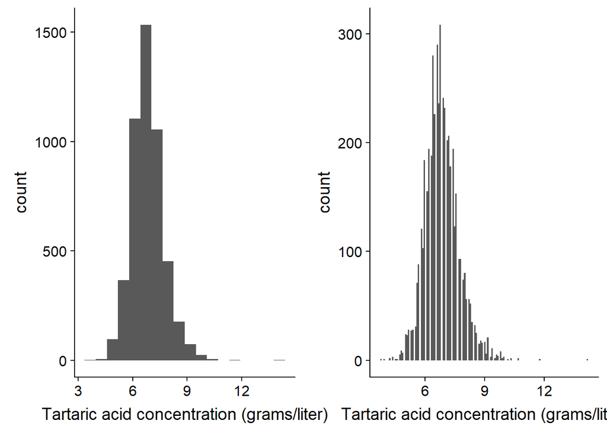

```
## [1] ""
## [1] "Shapiro-Wilks normality test p-values"
## [1] ""
## [1] "Data:"                "1.15015090710102e-27"
## [1] "Log of Data:"        "3.7218759449922e-15"
```

```
## [1] 7
```

##### Acetic acid concentration (volatile acidity)

The median acetic acid concentration is about 26 times less than the tartaric acid concentration, so its contribution to the acidity is relatively low. However, too much acetic acid may reduce a wine’s quality rating since it will start to have a vinegar flavor. The acetic acid concentration has a much more pronounced tail on the right compared with tartaric acid. The values range over more than a factor of 10.

```
##  volatile.acidity
##  Min.   :0.0800
##  1st Qu.:0.2100
##  Median :0.2600
##  Mean   :0.2782
##  3rd Qu.:0.3200
##  Max.   :1.1000
```

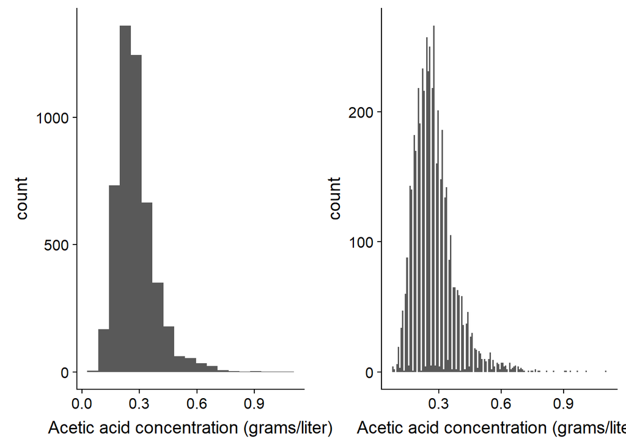

```
## [1] ""
## [1] "Shapiro-Wilks normality test p-values"
## [1] ""
## [1] "Data:"                "4.58679708717852e-48"
## [1] "Log of Data:"         "7.68454633373074e-11"
```

##### Citric acid concentration

The citric acid concentrations are comparable to the acetic acid concentrations, but the tail on the right is even longer and there are apparently 19 wines with either no measurable citric acid or citric acid concentration was not measured for those wines.

```
##   citric.acid
##  Min.   :0.0000
##  1st Qu.:0.2700
##  Median :0.3200
##  Mean   :0.3342
##  3rd Qu.:0.3900
##  Max.   :1.6600
```

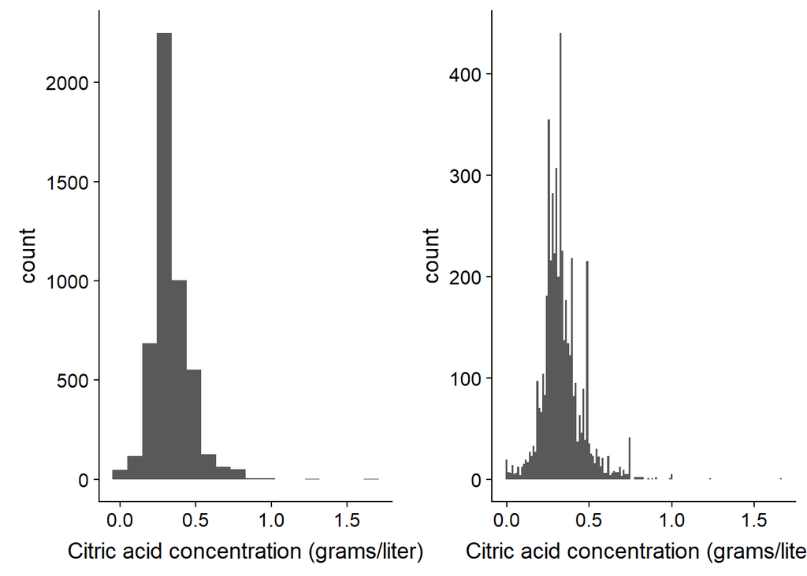

```
## [1] ""
## [1] "Shapiro-Wilks normality test p-values"
## [1] ""
## [1] "Data:"               "1.0131790644845e-44"
## [1] "Log of Data:"         "4.90214038064474e-54"
```

```
## [1] 19
```

### Sugar concentration

The sugar concentration has several peaks. This cannot be seen using the Doane criterion for the number of bins, but is seen with 8 times more bins and is easily seen using a log scale with 4 times more bins. There is a large peak at a concentration of about 1.5 grams/liter and smaller peaks around 5, 8, and 14 grams/liter. Based on the variable description, wines with greater than 45 grams/liter of sugar are considered sweet. There is only 1 wine in this data set which would be considered to be sweet, therefore this data set would not be useful for building a model to predict the quality of sweet wines. Also of possible concern if trying to use any model built from this data set for prediction is that the variable description says that having a sugar concentration of less than 1 gram/liter is rare, but 77 or 1.57% of the wines in this data set have those concentrations. This seems like more than rare, but the term “rare” is subjective.

```
##  residual.sugar
##  Min.   : 0.600
##  1st Qu.: 1.700
##  Median : 5.200
##  Mean   : 6.391
##  3rd Qu.: 9.900
##  Max.   :65.800
```

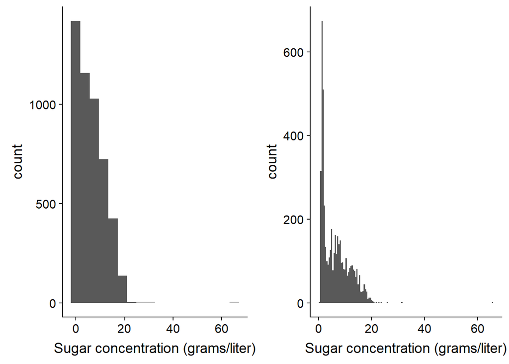

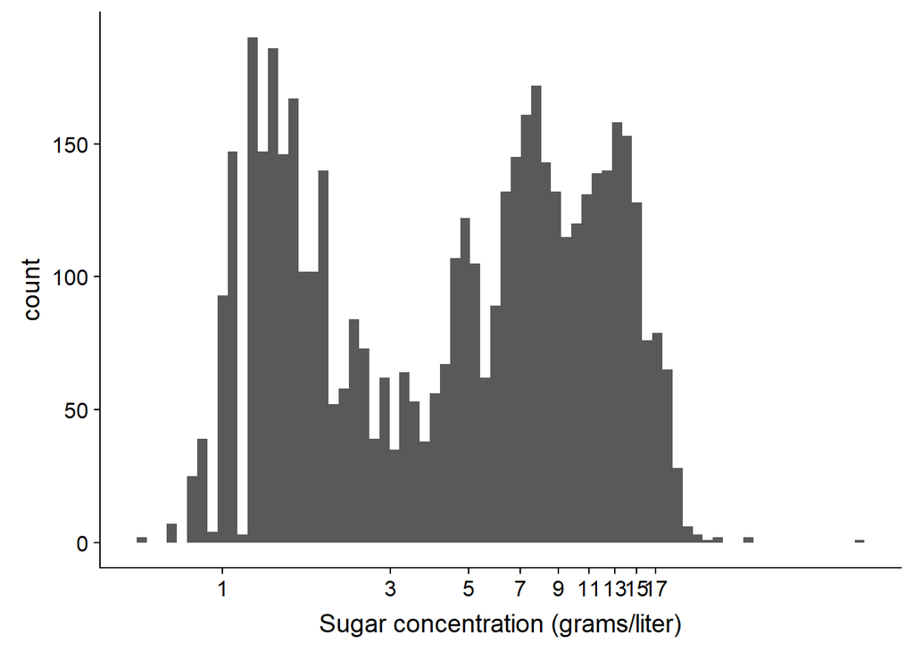

```
## [1] ""
## [1] "Shapiro-Wilks normality test p-values"
## [1] ""
## [1] "Data:"                "2.82071009155741e-51"
## [1] "Log of Data:"         "6.36823925684711e-43"
```

```
## [1] 1
```

```
## [1] 77
```

```
## [1] 1.57207
```

### Chloride concentration

The chloride ions in wine are primarily due to sodium chloride, and most wines in this data set have a concentration of less than 0.1 grams/liter. However, the distribution has a very long tail, with concentrations as high as 0.346 grams/liter. All of the chloride concentrations are low. For comparison, fresh water generally has a concentration of around 0.1 grams/liter of sodium chloride (https://www.engineeringtoolbox.com/water-salinity-d_1251.html).

```
##    chlorides
##  Min.   :0.00900
##  1st Qu.:0.03600
##  Median :0.04300
##  Mean   :0.04577
##  3rd Qu.:0.05000
##  Max.   :0.34600
```

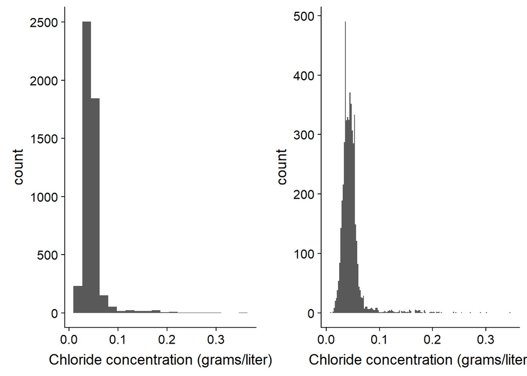

```
## [1] ""
## [1] "Shapiro-Wilks normality test p-values"
## [1] ""
## [1] "Data:"                "2.14058405766154e-75"
## [1] "Log of Data:"         "1.23237572908973e-46"
```

### Sulfur compounds

#### Free sulfur dioxide

The data description says that free sulfur dioxide does not influence the smell or taste of wine until the concentration exceeds about 50 milligrams/liter. In this data set, 932 or about 19% of the wines have free sulfur dioxide concentrations above this threshold with the highest concentration being 289 milligrams/liter. This suggests that the correlation between free sulfur dioxide concentration and quality should be investigated on two subsets of the data with free sulfur dioxide concentrations above and below the threshold.

```
##  free.sulfur.dioxide
##  Min.   :  2.00
##  1st Qu.: 23.00
##  Median : 34.00
##  Mean   : 35.31
##  3rd Qu.: 46.00
##  Max.   :289.00
```

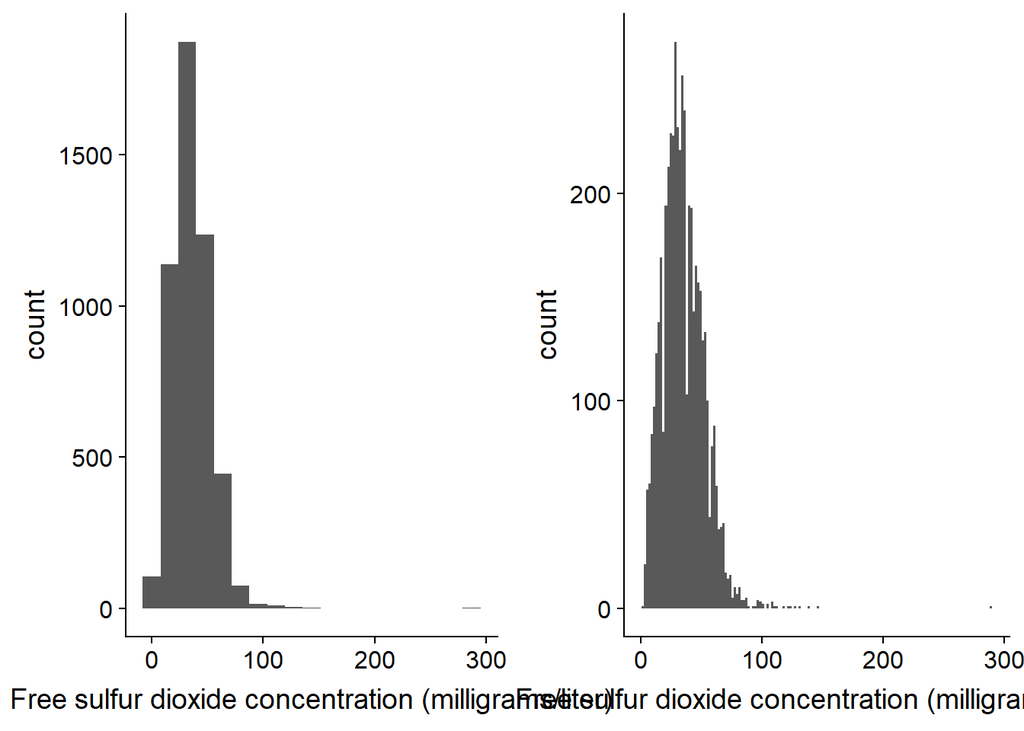

```
## [1] ""
## [1] "Shapiro-Wilks normality test p-values"
## [1] ""
## [1] "Data:"                "3.85784547949475e-40"
## [1] "Log of Data:"         "5.42344825692312e-37"
```

```
## [1] 932
```

```
## [1] 19.02817
```

#### Total sulfur dioxide

The total sulfur dioxide concentration distribution has a similar shape to the free sulfur dioxide concentration distribution, but the mean is about 100 milligrams/liter higher than the mean for free sulfur dioxide concentration. This means that the majority of the sulfur dioxide is in the bound form; about 74% on average.

```
##  total.sulfur.dioxide
##  Min.   :  9.0
##  1st Qu.:108.0
##  Median :134.0
##  Mean   :138.4
##  3rd Qu.:167.0
##  Max.   :440.0
```

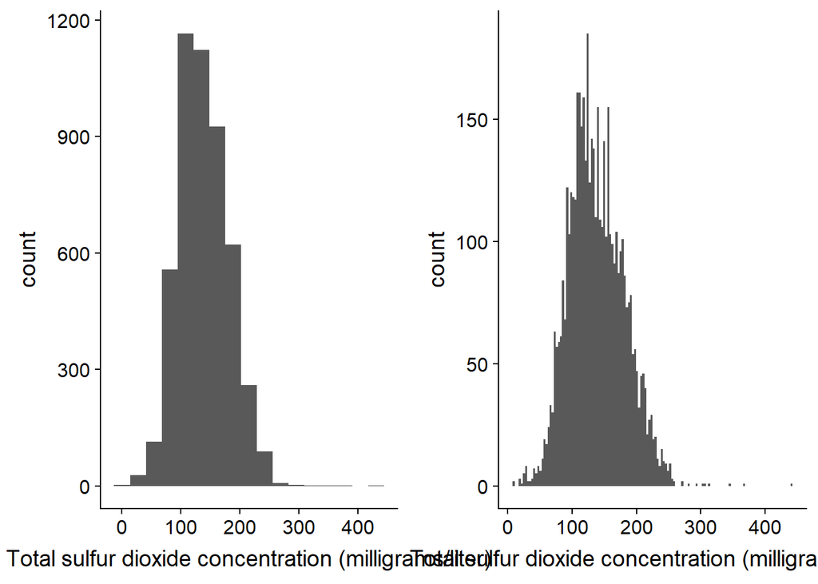

```
## [1] ""
## [1] "Shapiro-Wilks normality test p-values"
## [1] ""
## [1] "Data:"                "4.38345273614437e-19"
## [1] "Log of Data:"         "1.52895717843293e-35"
```

```
## [1] 74.4423
```

#### Potassium sulphate

[output not shown]

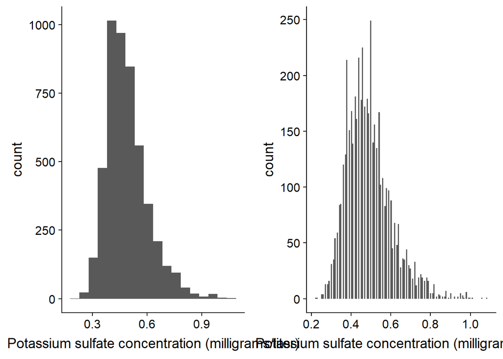

```
## [1] ""
## [1] "Shapiro-Wilks normality test p-values"
## [1] ""
## [1] "Data:"                "1.82197909317035e-37"
## [1] "Log of Data:"         "3.13620373624129e-11"
```

### pH

The pH is approximately normally distributed with a mean of about 3.2. The Wikipedia article on acids in wine (https://en.wikipedia.org/wiki/Acids_in_wine) states that wine pH is usually between 2.9 and 3.9 so the distribution is reasonble. However, there are 70 (1.4%) wines with a pH between 2.7 and 2.9.

```
##        pH
##  Min.   :2.720
##  1st Qu.:3.090
##  Median :3.180
##  Mean   :3.188
##  3rd Qu.:3.280
##  Max.   :3.820
```

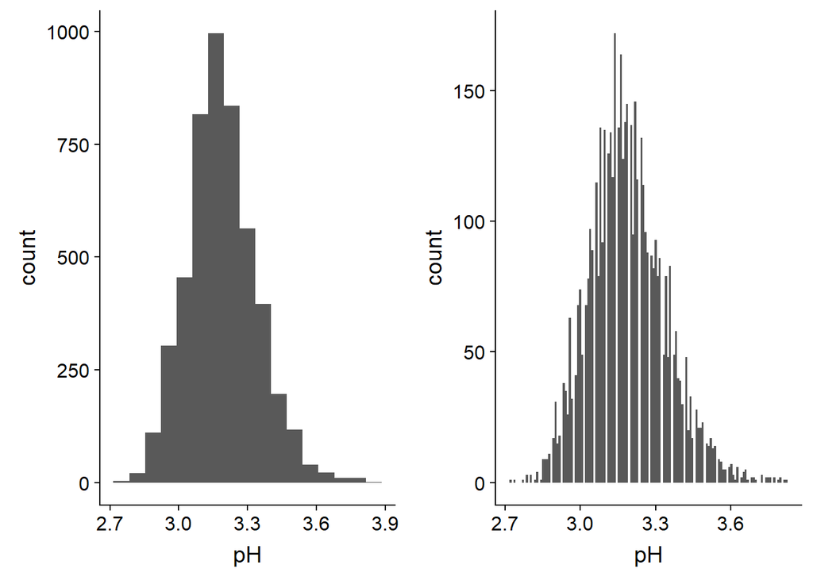

```
## [1] ""
## [1] "Shapiro-Wilks normality test p-values"
## [1] ""
## [1] "Data:"                "6.50552109665611e-20"
## [1] "Log of Data:"         "3.92052531839503e-13"
```

```
## [1] 70
```

```
## [1] 1.429155
```

### Alcohol

The distribution of alcohol content is right skewed. The mean is about 10.5% and the max is 14.2%.

```
##     alcohol
##  Min.   : 8.00
##  1st Qu.: 9.50
##  Median :10.40
##  Mean   :10.51
##  3rd Qu.:11.40
##  Max.   :14.20
```

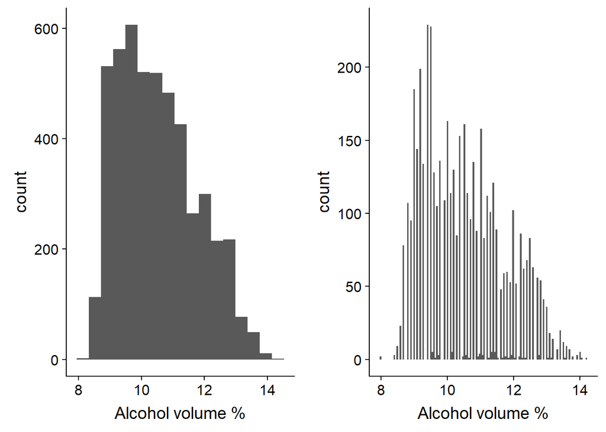

```
## [1] ""
## [1] "Shapiro-Wilks normality test p-values"
## [1] ""
## [1] "Data:"                "2.56901438494661e-36"
## [1] "Log of Data:"        "1.2814053375638e-32"
```

### Density

The densities are narrowly distributed and have a mean slightly less than the density of water which is expected since alcohol lowers the density. The distribution appears to be approximately normal, but there are some outliers with densities of around 1.01 and 1.04 g/cc. These measurements are suspect since they are significantly larger than other measurements and it is unlikely that the density of a wine is significantly higher than water.

```
##     density
##  Min.   :0.9871
##  1st Qu.:0.9917
##  Median :0.9937
##  Mean   :0.9940
##  3rd Qu.:0.9961
##  Max.   :1.0390
```

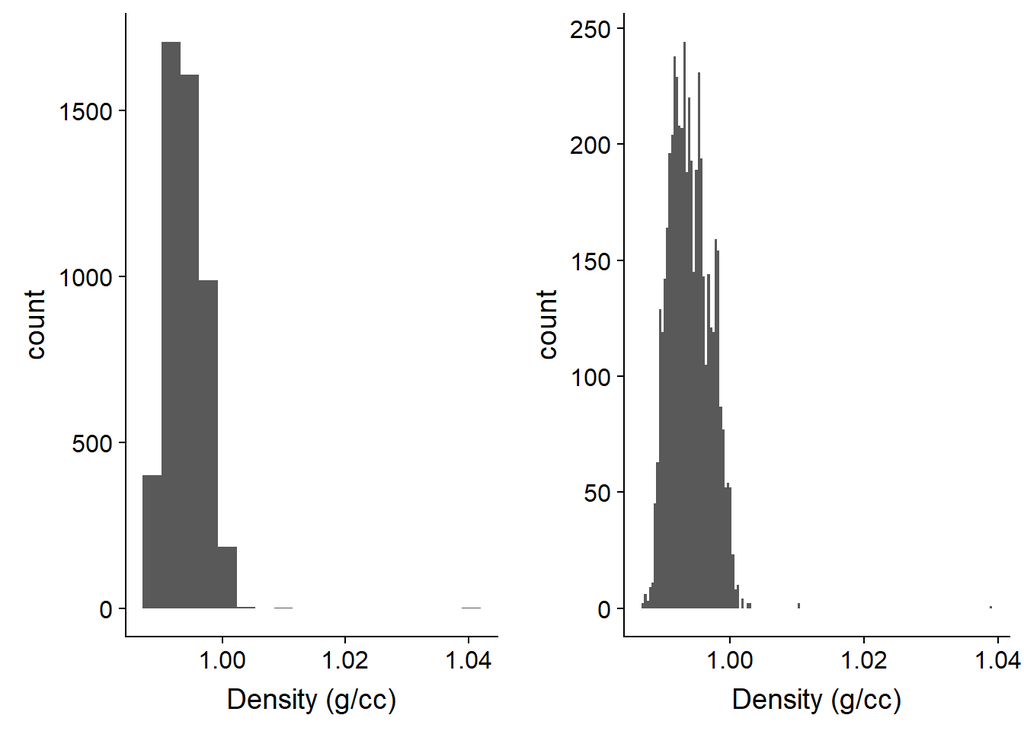

```
## [1] ""
## [1] "Shapiro-Wilks normality test p-values"
## [1] ""
## [1] "Data:"                "1.78089468319201e-36"
## [1] "Log of Data:"        "6.0464797347972e-36"
```

### Quality

Quality is restricted to integers between 0 and 10, so the histogram is plotted with a bin width of 1. The minimum quality is 3 and the maximum quality is 9. Both the median and the mode are 6.

```
##     quality
##  Min.   :3.000
##  1st Qu.:5.000
##  Median :6.000
##  Mean   :5.878
##  3rd Qu.:6.000
##  Max.   :9.000
```

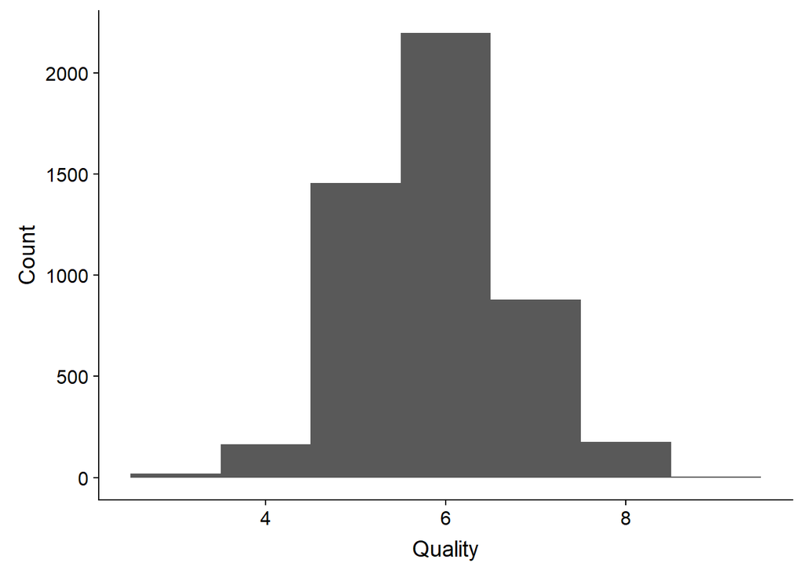

# Single variable summary

## Data structure

This data set consists of quality scores for 4898 Portuguese white wines. Also included are 10 measurements of the concentrations of various chemical species in the wines and the densities of the wines which might be correlated with the quality scores. Those concentrations are of tartaric acid, acetic acid, citric acid, sugar, chloride, free sulfur dioxide, total sulfur dioxide, potassium sulfate, pH, and alcohol.

## Distributions of variables and potential outliers

None of the distributions are normal based on the Shapiro-Wilks test. However, the distributions of tartaric acid concentration, total sulfur dioxide concentration, and density appear to be approximately symmetric. The sugar concentration distribution is multimodal.

There are some outliers and atypical distributions which may be of concern and taken into account in later analysis. The density data appears to have a few outliers with unrealistically high densities which might need to discarded. There are 19 wines which have a reported citric acid concentration of zero. It is unlikely that the concentrations are actually zero. For some analysis, it might be better to exclude these wines. Only free sulfur dioxide concentrations above about 50 mg/L affect the smell and taste of a wine. Only 19% of the wines have free sulfur dioxide concentrations above this threshold. When considering correlation of free sulfur dioxide concentration with quality, it would be best to split the data into two groups, one below and one above the threshold concentration. The reason for the multimodal distribution of sugar concentration is not known. Perhaps this is related to different classes of wines with different typical sugar concentrations that are targets of producers. However, without other data there is not really much basis for segmenting the data based on sugar concentration during analysis. There is only one wine in the data set which is considered sweet (sugar concentration > 45 g/L), so this data set could not be used to build a model which would predict the quality of sweet wines. There are also a relatively large number of wines, 70, with pH values outside the typical range of 2.9-3.9. This could be a problem if trying to use only this data set to create a general model for predicting wine quality.

## Importance of measurements for determining quality score based on a support vector machine model

Cortez et al.[1] reported the importance of each measurment in determining the quality scored based on a support vector machine model. The order of the importances was potassium sulfate > alcohol > sugar > citric acid > total sulfur dioxide > free sulfur dioxide > acetic acid > density > pH > chloride > tartaric acid. None of the concentrations appear to have a negligible effect, with the smallest effect being about 2.5% and the largest being about 20%. However, many of the measurements are expected to be correlated due to chemical considerations. It also seems unlikely that the density by itself would have much effect on the quality score, and the effect seen is likely due to its correlations with other variables. The correlations are investigated in the next section.

[1] Cortez, P.; Cerdeira, A.; Almeida, F.; Matos, T.; Reis, J. Modeling Wine Preferences by Data Mining from Physicochemical Properties. Decision Support Systems 2009, 47 (4), 547-553. https://doi.org/10.1016/j.dss.2009.05.016.

# Two variables

There are expected to be correlations between sulphate concentration, sulfur dioxide concentrations, and pH; acid concentrations and pH; and also between density, alcohol concentration, and sugar concentration.

## Remove outliers

Some potential outliers were noted in the single variable analysis. Here outliers are identified by Rosner’s test and changed to NA before looking at correlations between two variables. Rosner’s test assumes the data are from a normal distribution, so first a transformation is done using Tukey’s Ladder of Powers to make the data more normal. For variables with identified outliers, box plots of the transformed variables are created. For calculating correlations, the outliers are just blindly removed by replacing the values with NA. For creating a model, there should probably be a more careful consideration of whether or not values are really outliers.

```
## Number of outliers for fixed.acidity : 3
```

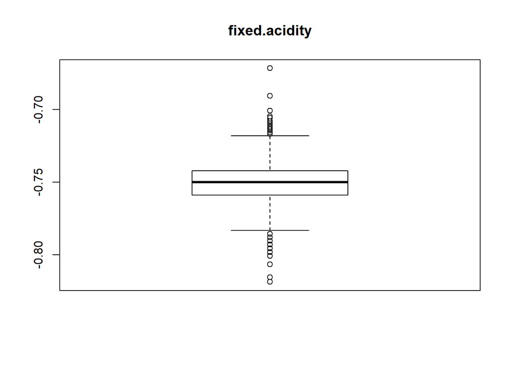

```
## Number of outliers for volatile.acidity : 0
## Number of outliers for citric.acid : 8
```

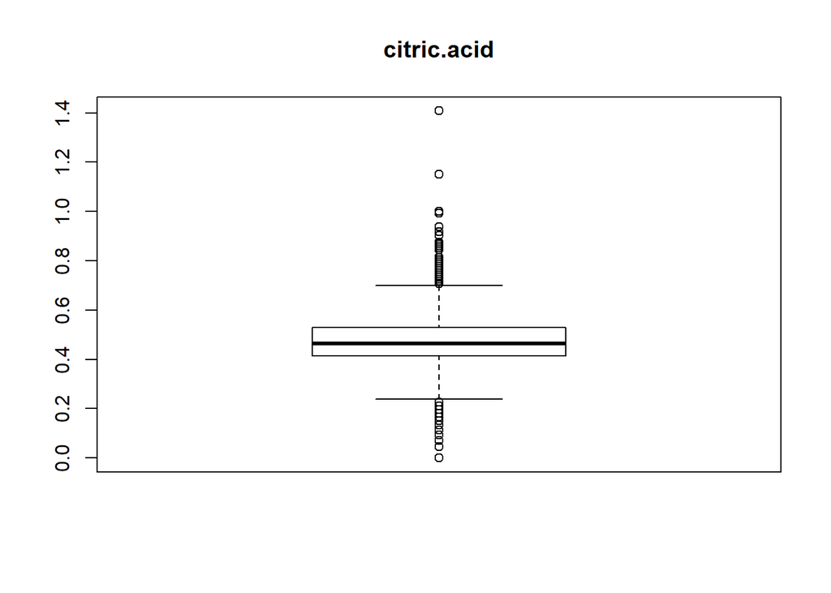

```
## Number of outliers for residual.sugar : 0
## Number of outliers for chlorides : 7
```

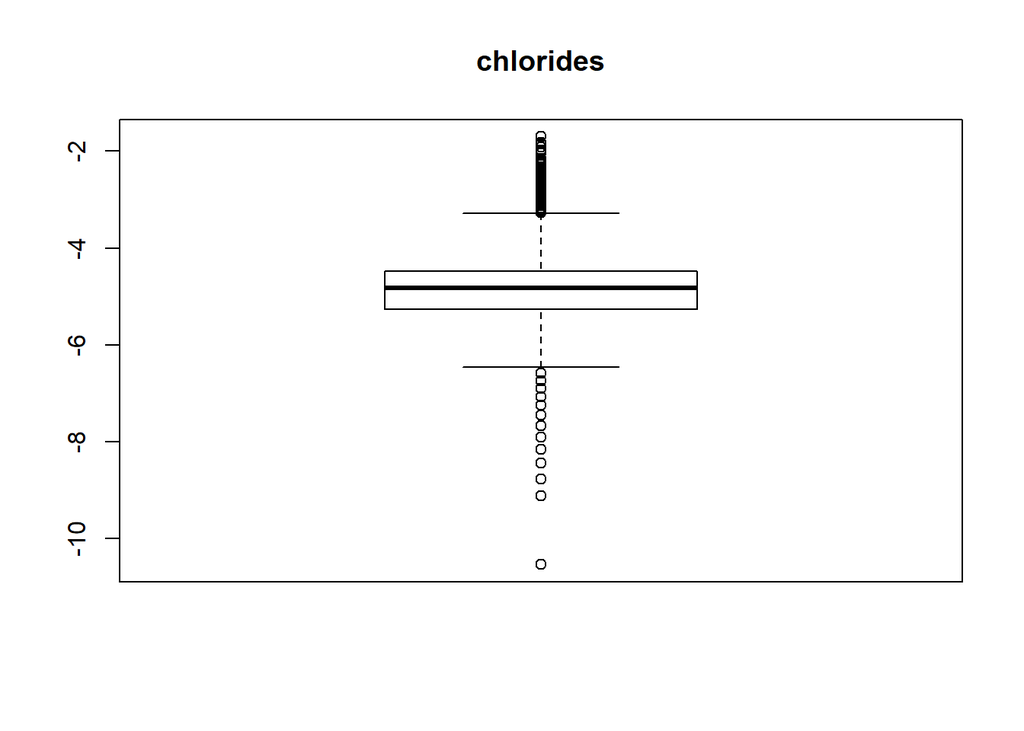

```
## Number of outliers for free.sulfur.dioxide : 1
```

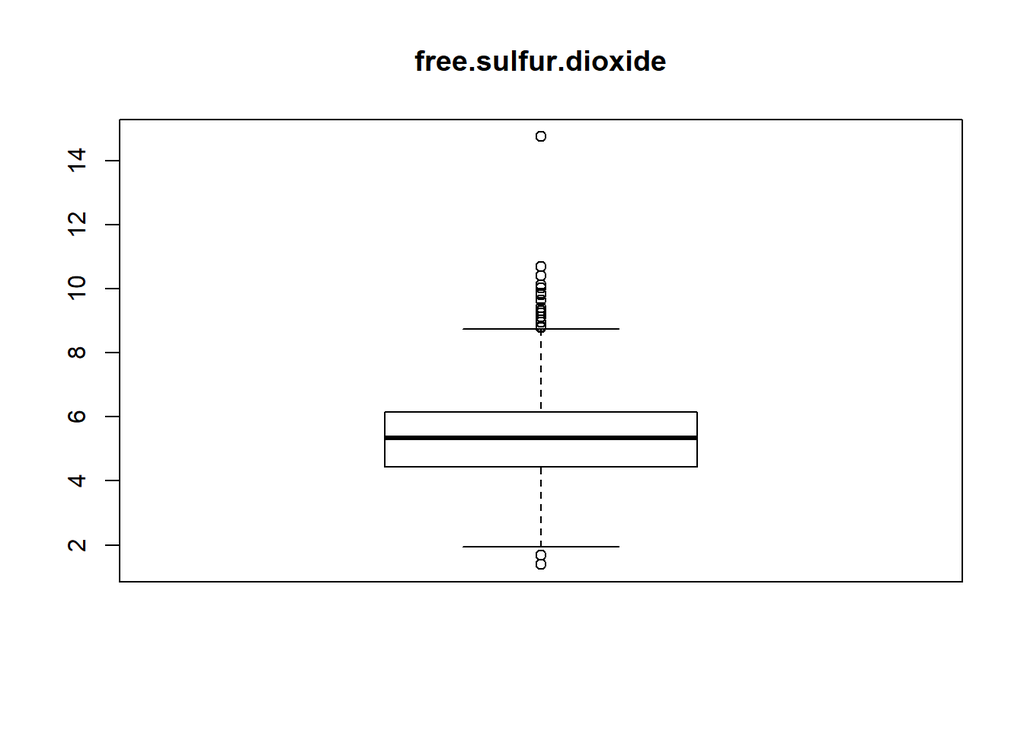

```
## Number of outliers for total.sulfur.dioxide : 1
```

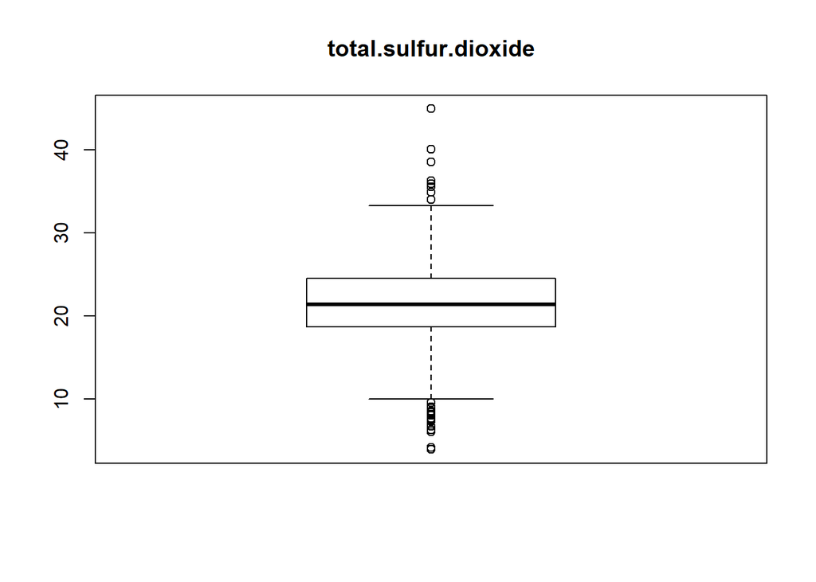

```
## Number of outliers for density : 3
```

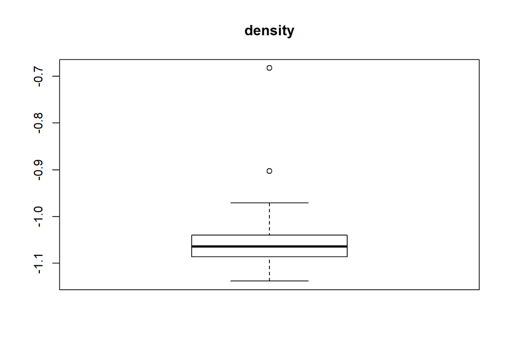

```
## Number of outliers for pH : 0
## Number of outliers for sulphates : 0
## Number of outliers for alcohol : 0
## Number of outliers for quality : 0
```

After running Rosner’s test on each variable in the data frame once, 23 outliers were found. Although some box plots show many points outside the whiskers, most of those points are still near the whiskers. Only the points far from the whiskers are determined to be outliers by Rosner’s test. Since the outliers may affect the data transformation, multiple iterations are performed with the data input to the next iteration being the data with outliers removed from the previous iteration.

```
## Number of outliers for fixed.acidity : 0
## Number of outliers for volatile.acidity : 0
## Number of outliers for citric.acid : 0
## Number of outliers for residual.sugar : 0
## Number of outliers for chlorides : 4
```

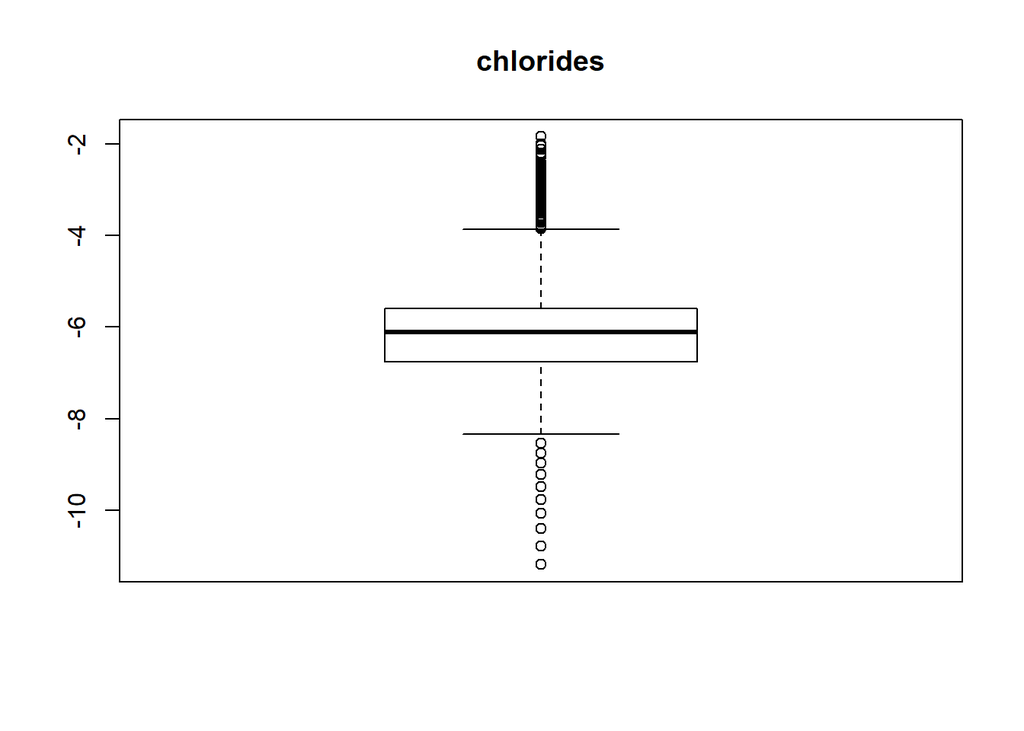

```
## Number of outliers for free.sulfur.dioxide : 1
```

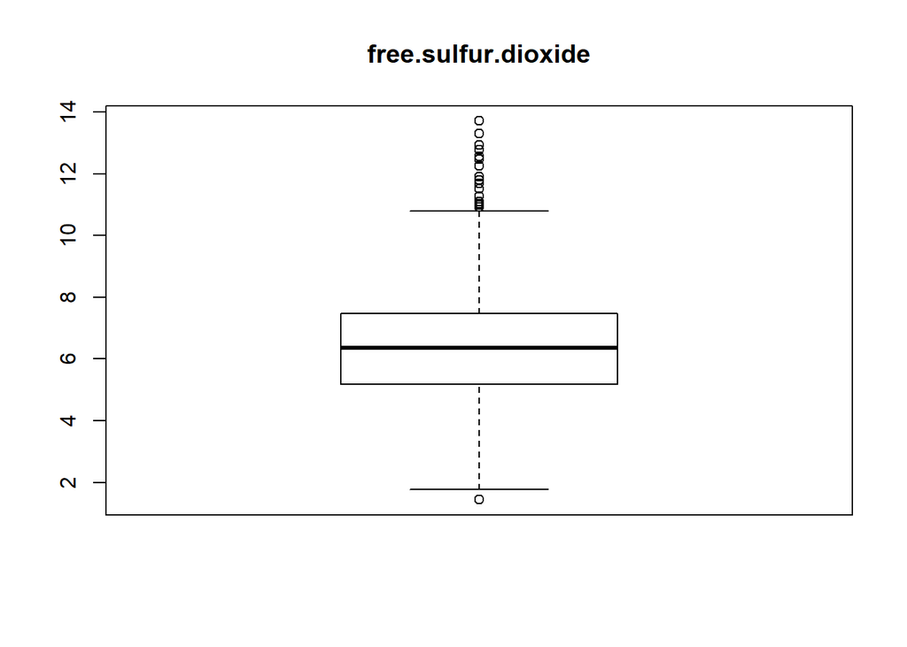

```
## Number of outliers for total.sulfur.dioxide : 1
```

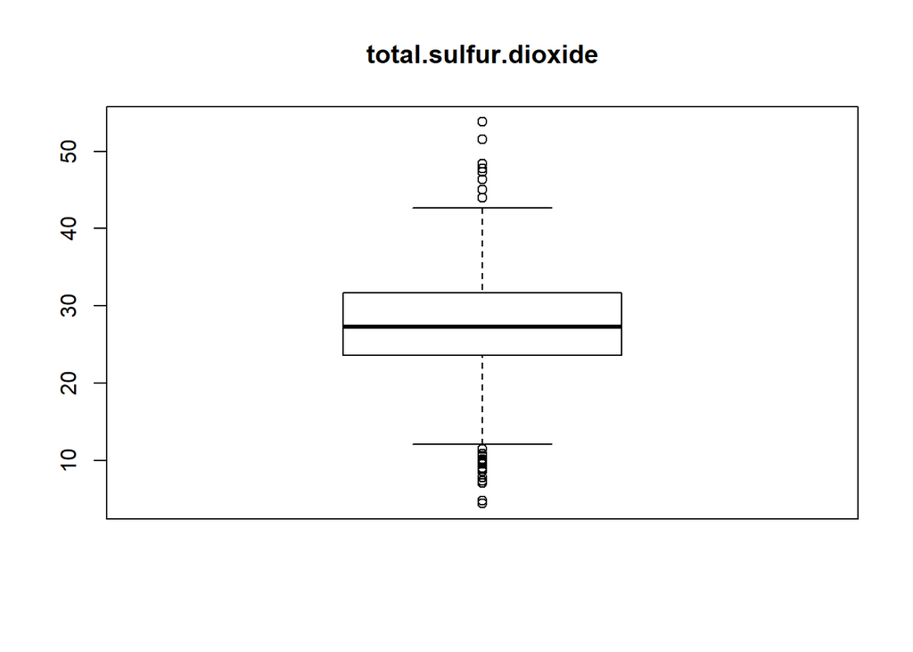

```
## Number of outliers for density : 0
## Number of outliers for pH : 0
## Number of outliers for sulphates : 0
## Number of outliers for alcohol : 0
## Number of outliers for quality : 0
```

After the second iteration, 6 more outliers are identified.

```
## Number of outliers for fixed.acidity : 0
## Number of outliers for volatile.acidity : 0
## Number of outliers for citric.acid : 0
## Number of outliers for residual.sugar : 0
## Number of outliers for chlorides : 0
## Number of outliers for free.sulfur.dioxide : 0
## Number of outliers for total.sulfur.dioxide : 0
## Number of outliers for density : 0
## Number of outliers for pH : 0
## Number of outliers for sulphates : 0
## Number of outliers for alcohol : 0
## Number of outliers for quality : 0
```

After the third iteration, no more outliers are identified.

```
## [1] 19
```

Rosner’s test did not identify the 19 citric acid concentrations that are zero as outliers. Since it seems physically unrealistic to have a concentration of exactly zero, these points are also changed to NA for the purpose of calculating correlations.

```
## [1] 0
```

## Correlations

Pearson correlations and Spearman rank correlations are calculated using transformed data after removing outliers. Since the Pearson correlation assumes data is normally distributed, again the data is transformed using Tukey’s ladder of powers. The correlations are split into groups with weakly correlated variables having correlation magnitudes between 0.1 and 0.3, moderately correlated variables having magnitudes between 0.3 and 0.5, and strongly correlated variables having magnitudes greater than 0.5. Pairs of variables with correlation magnitudes less than 0.1 are not looked at further.

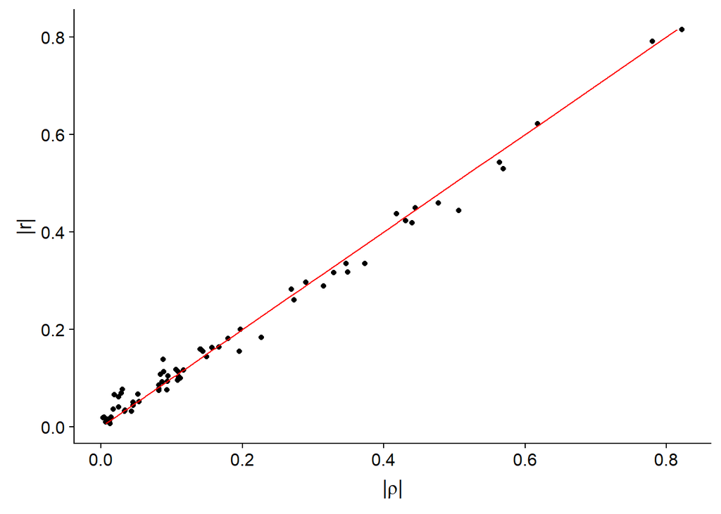

Pearson’s r and Spearman’s ρ are very close to each other in most cases. A value of r with a smaller magnitude compared to ρ (below the red line in the plot above) may indicate a nonlinear relationship between the transformed variables.

### Weakly correlated variables

```
##                     row               column      r    rho
## 2         fixed.acidity          citric.acid  0.297  0.290
## 3      volatile.acidity          citric.acid -0.155 -0.144
## 4         fixed.acidity       residual.sugar  0.096  0.108
## 5      volatile.acidity       residual.sugar  0.113  0.109
## 10       residual.sugar            chlorides  0.184  0.227
## 15            chlorides  free.sulfur.dioxide  0.164  0.167
## 16        fixed.acidity total.sulfur.dioxide  0.100  0.112
## 17     volatile.acidity total.sulfur.dioxide  0.117  0.117
## 18          citric.acid total.sulfur.dioxide  0.113  0.089
## 22        fixed.acidity              density  0.283  0.269
## 24          citric.acid              density  0.139  0.088
## 31          citric.acid                   pH -0.159 -0.141
## 32       residual.sugar                   pH -0.182 -0.180
## 36              density                   pH -0.103 -0.110
## 43 total.sulfur.dioxide            sulphates  0.163  0.157
## 44              density            sulphates  0.105  0.095
## 45                   pH            sulphates  0.160  0.140
## 46        fixed.acidity              alcohol -0.118 -0.106
## 51  free.sulfur.dioxide              alcohol -0.260 -0.273
## 54                   pH              alcohol  0.144  0.149
## 56        fixed.acidity              quality -0.108 -0.084
## 57     volatile.acidity              quality -0.200 -0.197
## 62 total.sulfur.dioxide              quality -0.155 -0.196
## 64                   pH              quality  0.098  0.109
```

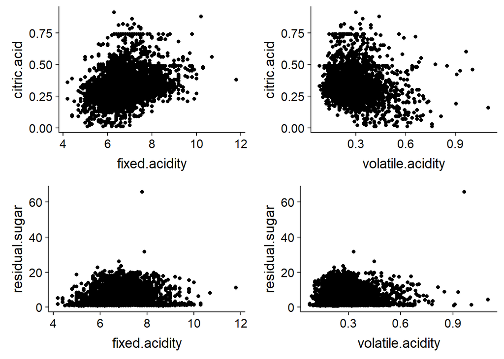

### Moderately correlated variables

```
##                     row               column      r    rho
## 14       residual.sugar  free.sulfur.dioxide  0.335  0.347
## 19       residual.sugar total.sulfur.dioxide  0.423  0.431
## 20            chlorides total.sulfur.dioxide  0.335  0.373
## 27  free.sulfur.dioxide              density  0.317  0.329
## 29        fixed.acidity                   pH -0.437 -0.418
## 49       residual.sugar              alcohol -0.449 -0.445
## 52 total.sulfur.dioxide              alcohol -0.459 -0.477
## 60            chlorides              quality -0.289 -0.315
## 63              density              quality -0.318 -0.349
## 66              alcohol              quality  0.419  0.440
```

### Strongly correlated variables

```
##                     row               column      r    rho
## 21  free.sulfur.dioxide total.sulfur.dioxide  0.622  0.618
## 25       residual.sugar              density  0.791  0.780
## 26            chlorides              density  0.444  0.506
## 28 total.sulfur.dioxide              density  0.543  0.564
## 50            chlorides              alcohol -0.529 -0.569
## 53              density              alcohol -0.815 -0.822
```